# Assignment 10

July 27, 2018

## Contents

- Data
  - Down-Sampling
- GBM
  - Modeling
  - Grid-Search
  - Best Model
  - ROC and Precision-Recall
  - Variable Importance and Partial Dependence Plots

## Data

## Data - Down-Sampling

As we can see from the below table, we have an extremely unbalanced data.  
When we look at a table of `Class` variable, fraud class(\(1\)) take only \(0.173\)%.  
Therefore,  
1. We need to do down-sampling to balance the imbalanced dataset.  
2. We need to come up with the right evaluation metrics later on.

```
##
##      0      1
## 284315    492
```

## Data - Down-Sampling

This time, I slightly increased the samples size of `Class == 0`. I sampled \(5500\) observations from the Class \(0\).

```
##
##    0    1
## 5500  492
```

## GBM

## GBM - Modeling

After initializing the h2o,  
1. I changed the dataset into h2o data frame format,  
2. split the dataset into `train`, `valid`, and `test` set, and  
3. set the response and predictive variables respectively.

## GBM - Modeling

I tried a modeling with random hyper-parameters, and then printed auc on the validation data.

[output not shown]

```
## [1] 0.9630935
```

## GBM - Grid-Search

To find the best combination of hyper-parameters, I am going to conduct grid-search.  
After doing the grid search, I sorted the model by descending order of AUC, to find the best model to use.

```
## H2O Grid Details
## ================
##
## Grid ID: my_grid
## Used hyper parameters:
##   -  max_depth
##   -  ntrees
## Number of models: 25
## Number of failed models: 0
##
## Hyper-Parameter Search Summary: ordered by decreasing auc
##   max_depth ntrees        model_ids                auc
## 1         5    700 my_grid_model_16 0.9796018089142681
## 2         5    900 my_grid_model_21 0.9796018089142681
## 3         5    500 my_grid_model_11 0.9796018089142681
## 4         5    300  my_grid_model_6 0.9794772544360556
## 5         5    100  my_grid_model_1 0.9751370099260339
##
## ---
##    max_depth ntrees        model_ids                auc
## 20        14    900 my_grid_model_24 0.9718171540259839
## 21         8    700 my_grid_model_17 0.9703751964128311
## 22         8    300  my_grid_model_7 0.9703751964128311
## 23         8    500 my_grid_model_12 0.9703751964128311
## 24         8    900 my_grid_model_22 0.9703751964128311
## 25         2    100  my_grid_model_0 0.9685452036944774
```

## GBM - Best Model

I set the best model as the one with the highest AUC from the grid-search result.  
I printed the variable importances, the number of trees, and the maximum depth of the tree, used in my best model.

```
## [1] "The top 5 important variables: V14 V10 V12 V4 V11"
```

```
## [1] "In my best model, the number of trees is 380"
```

```
## [1] ", and maximum depth of the tree is 5"
```

## GBM - Best Model

If I compare the AUC results on validation data, we can find that the AUC has been improved.

```
## [1] "The AUC with random hyper parameters was: 0.963094"
```

```
## [1] "The AUC with the gird-search best model is: 0.979602"
```

## GBM - Best Model

Finally, I tested on my `test` data as well.

```
## [1] "MSE: 0.01229, RMSE: 0.11088, LogLoss: 0.0572"
```

```
## [1] "AUC: 0.9796, Gini: 0.95921"
```

## ROC and Precision-Recall

I plotted both `ROC` and `Precision-Recall` curve as follows.  
1. `ROC`: As we can see from the above plot, it is pretty much close to the top-left corner (Our AUC is around 0.98).

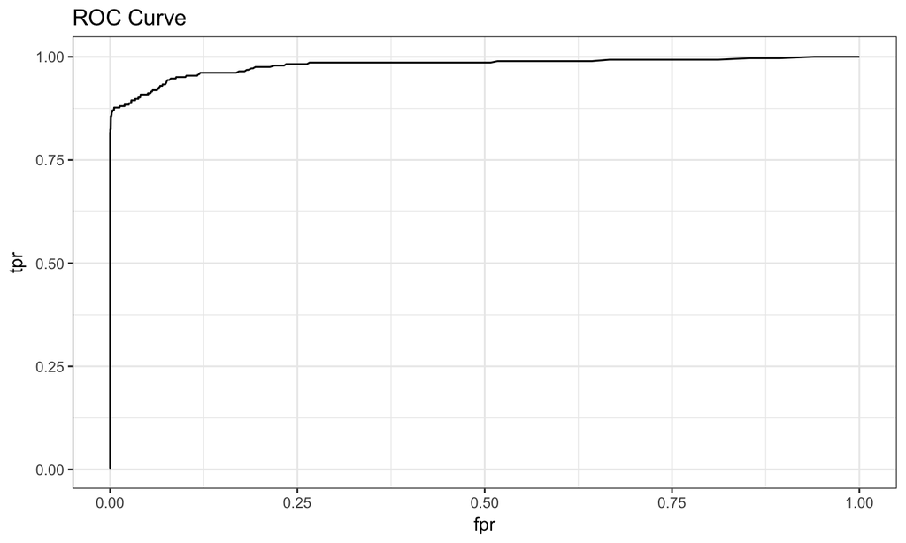

## ROC and Precision-Recall

2. `Precision-Recall`: I believe that since we have a quite imbalanced dataset, we better to look at the precision-recall curve since precision is directly influenced by class imbalance. Still, we can find that the graph is pretty much close to the upper-right corner, which is our optimum.

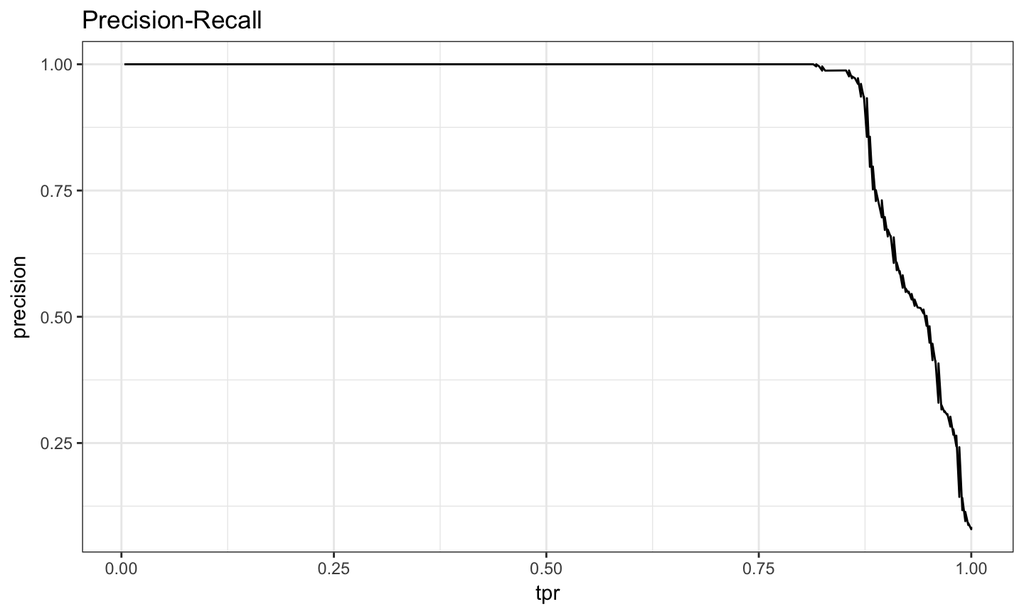

## Variable Importance

To conclude, I checked the Variable Importance and plotted Partial Dependence Plots.  
As we can see from the plot, `V14` was the most important variable in this model.

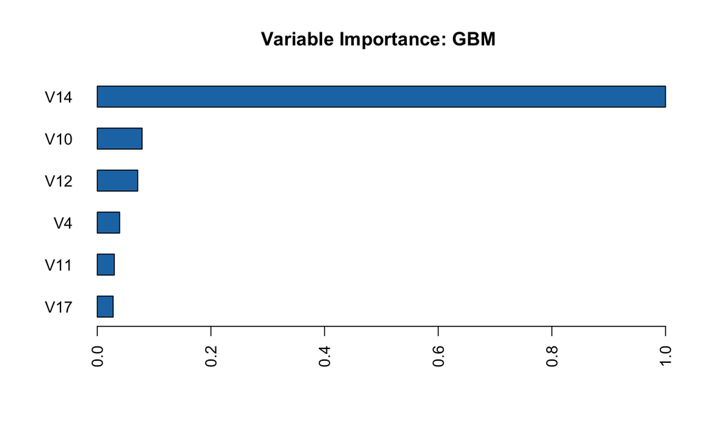

## Partial Dependence Plots

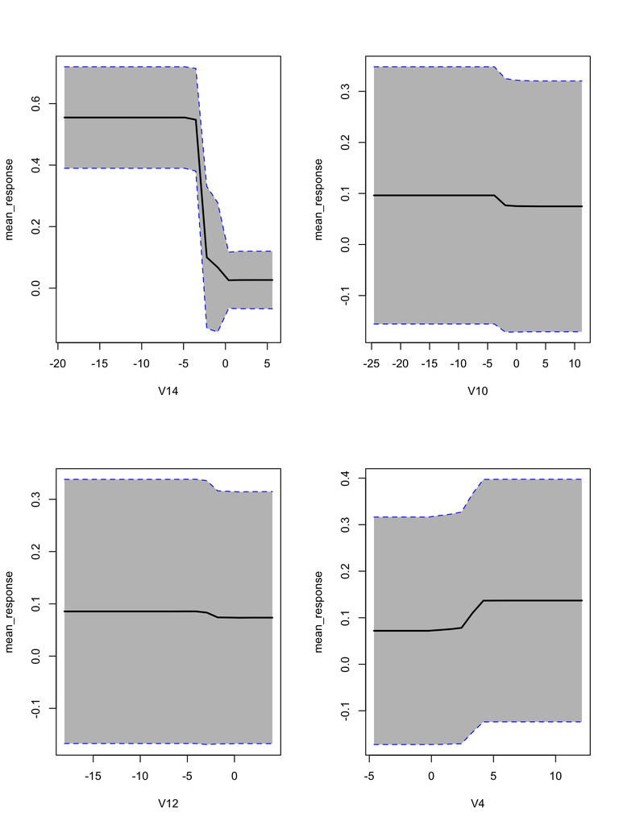

## Partial Dependence Plots

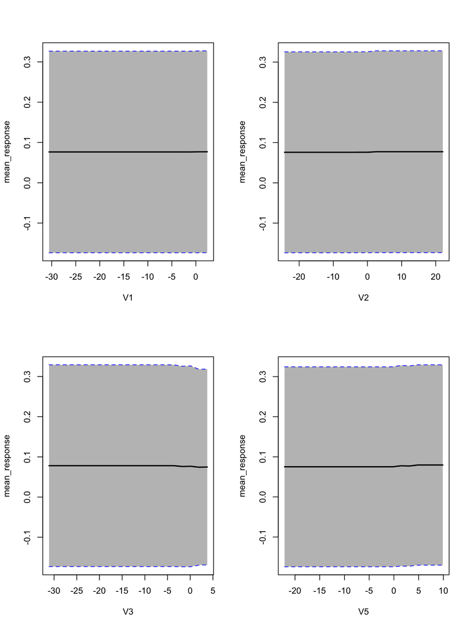

## Partial Dependence Plots

If we plot without standard deviations, we can differentiate whether a predictive variable has positive or negative on the response variable.

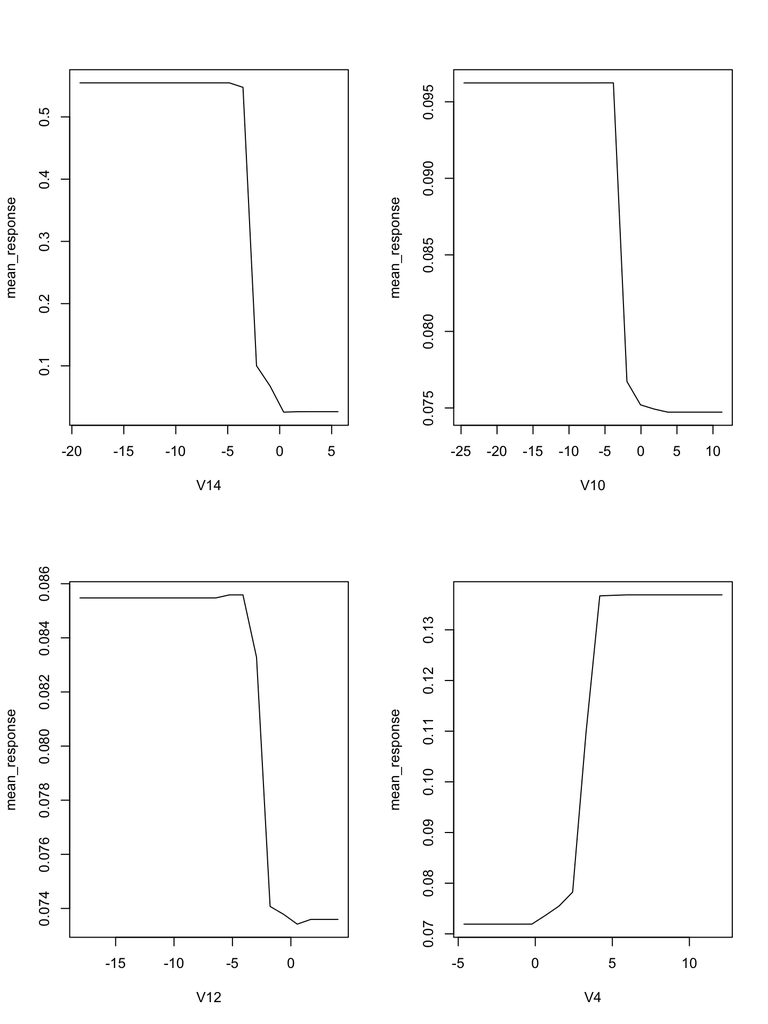

## Partial Dependence Plots

If we plot without standard deviations, we can differentiate whether a predictive variable has positive or negative on the response variable.

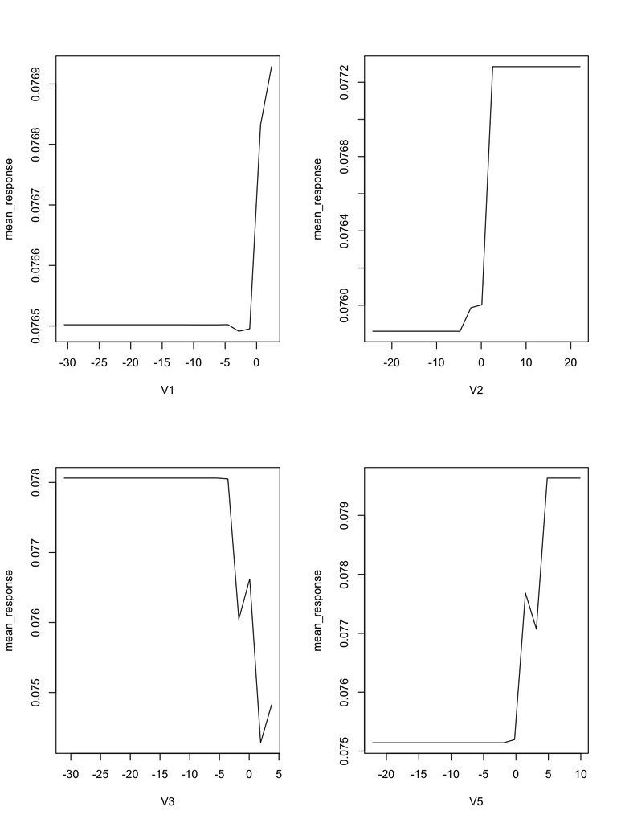